# Day 2 Markdown Lesson

Ben

Collaborator

Koji

11/17/2020

Abstract

This is an abstract. We doin work.

Lots of work

# HUGE

big

## LESS HUGE

lil big

### EH

fine

#### baybee

lil

# Intro to Markdown Syntax

Here is an example of **bold** text. Another example of **bold**

Example of *italics*. more *italic*.

Bold italic though, that shit is *wild*.

Superscript you just uses two<sup>karats</sup>.

For subscripts they’re<sub>tildes</sub>

Underlining doesn’t exist u dum dum. They do its just hard

### Line Breaks

Line 1 Line 2

Line 1  
Line 2

Line 1  
Line 2

* Note: that `<br>` does a line break and not a new paragraph.

#### Body of Document

This is our report introduction.

> This is a quote from an important persons

> Balls That is all.

> No but this is *REALLY* important

> > Beep boop balls

Paragraph 2

Paragraph 3

#### Lists

A numbered list

1. item 1
2. item 2
3. item 3

Can do Symbol lists too

- eggs
- milk
- cheese
- eggs
- milk
- cheese

And sublists

1. item 1  
   i. subitem 1
2. item 3  
   ii. subitem 2
3. item V  
   iii. subitem 14

> **Super** Important list
> 1. item 1
> 2. item 2
> 3. item 3

Paragraphs or descriptions udner list items

1. Item 1

   This is a description for item 1
2. Item 2

   This is a description for item 2
3. Item 3

   Item 3 is the best.

#### Tables in Markdown

| Col 1 | Col 2 | Col 3 | COl 4 |
| --- | --- | --- | --- |
| 1 | 1 | 1 | 1 |
| 1 | 2 | 3 | 4 |
| 4 | 3 | 2 | 1 |

#### Links and Graphics

Lets add a **link** to other information. Do that with http://rmarkdown.rstudio.com/lesson-1.html.

Or we can make it a link to text with [link](http://rmarkdown.rstudio.com/lesson-1.html)

# Code Chunks in Markdown

### Generate Data

```r
x <- rnorm(n = 100, mean = 5, sd =1)
```

```r
y <- 2 + 2*x + rnorm(n=length(x))
```

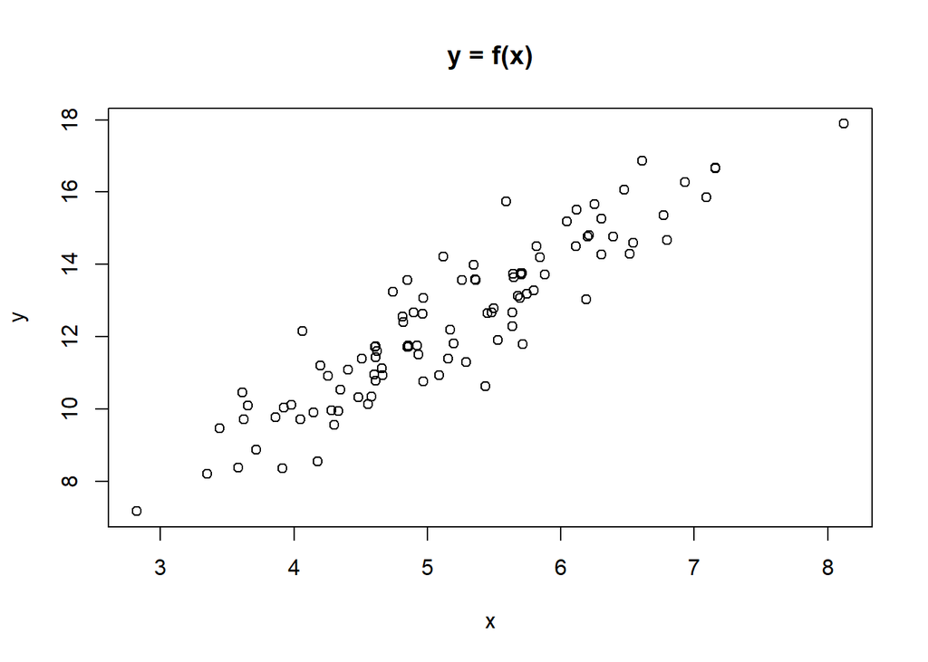

```r
plot(x, y, main = 'y = f(x)')
```

Include information between (x, y).

Our response variable is $y$ is disrupted $N(\mu, \sigma^2_y)$, where
$$\begin{align}
\mu &= 2 + 2E[x] + E[e] \\ [5pt]
\sigma^2 &= 2^2Var[x] + Var[e] + 2(2)Cov(x, e)
\end{align}$$

We see that $\mu =$ 12.4258443 and $\sigma^2 =$ 4.8897117. Lets round the output

$\mu =$ 12.43

$\sigma^2 =$ 4.89

$$y = f(x)$$

#### Working with Actual Data

```r
df_all <- read_csv('daily_bike_data.csv')
dftemp <- df_all %>% select(cnt,temp)
```

```r
ss_dftemp <- sapply(dftemp,
                    function(x) c(mean(x), min(x), max(x), sd(x))) %>%
  data.frame() %>%
  round(digits = 2)

row.names(ss_dftemp) <- c('mean','min','max','sd')
ss_dftemp %>% knitr::kable(caption = 'Summary Statistics')
```

Summary Statistics

|  | cnt | temp |
| --- | --- | --- |
| mean | 4504.35 | 0.50 |
| min | 22.00 | 0.06 |
| max | 8714.00 | 0.86 |
| sd | 1937.21 | 0.18 |

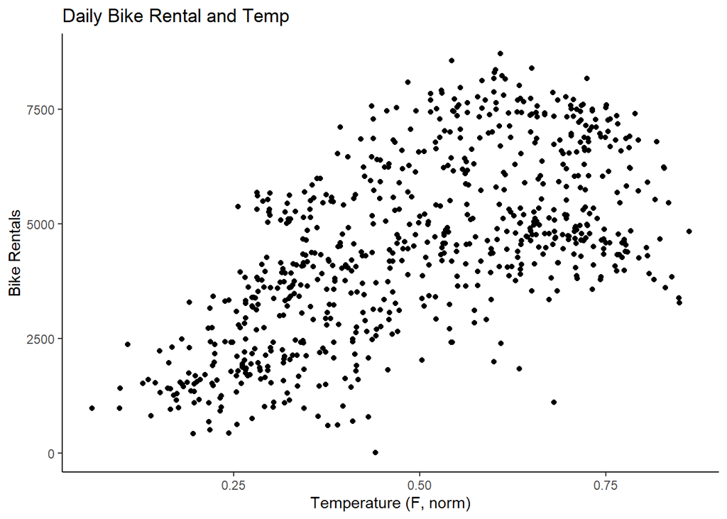

```r
ggplot(dftemp, aes(temp,cnt))+
  geom_point() +
  labs(title = 'Daily Bike Rental and Temp', x = 'Temperature (F, norm)',
       y = 'Bike Rentals')+ theme_classic()
```

```r
dftemp <- dftemp %>%
  mutate(temp2 = temp^2)

mod1 <- lm(formula = cnt ~ temp,
           data = dftemp)

mod2 <- lm(formula = cnt ~ temp + temp2,
           data = dftemp)

pred_mod1 <- predict(mod1, dftemp['temp'])

pred_mod2 <- predict(mod2, dftemp[c('temp','temp2')])

dftemp <- dftemp %>%
  mutate(cnt_mod1 = pred_mod1,
         cnt_mod2 = pred_mod2)
```

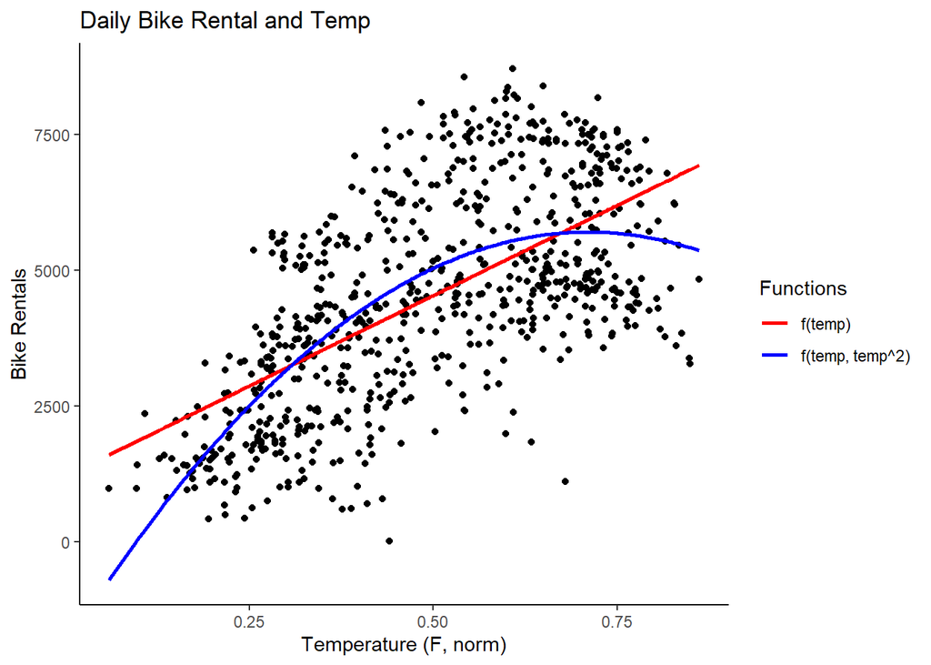

```r
ggplot(dftemp, aes(temp,cnt))+
  geom_point() +
  geom_line(aes(x = temp, y = cnt_mod1, color = 'f(temp)'), size = 1)+
  geom_line(aes(x = temp, y = cnt_mod2, color = 'f(temp, temp^2)'), size = 1)+
  labs(title = 'Daily Bike Rental and Temp', x = 'Temperature (F, norm)', y = 'Bike Rentals', color = 'Functions')+ theme_classic()+
  scale_color_manual(values = c('f(temp)' = 'red', 'f(temp, temp^2)' = 'blue'
  ))
```